# [Social Graphs & Interactions] Assignment 1

DTU - Semester 1

#### FORMALIA

**Due date and time**: The assignment is due on **Tuesday September 28th, 2021 at 23:59**. Hand in your IPython notebook file (with extension `.ipynb`) via http://peergrade.io/

*[Assignment overview page](https://github.com/SocialComplexityLab/socialgraphs2021/wiki/Assignments)*

```python
# IMPORTs
import matplotlib.pyplot as plt
import numpy as np
import random as rd
import networkx as nx
%matplotlib inline
```

# Part 1: Binning degree distributions

**Binning real numbers**

- Let's do a gentle start and use the `random` library to generate 5000 data points from a Gaussian distribution with $\mu = 2$ and $\sigma = 0.125$.

```python
mu, sigma, N = 2, 0.125, 5000
points = [rd.gauss(mu,sigma) for _ in range (N)]
```

- Now, let's use `numpy.histogram` to bin those number into 10 bins.

```python
histogram = np.histogram(points, 10)
histogram
```

```
(array([  19,  156,  636, 1365, 1581,  880,  310,   48,    4,    1],
       dtype=int64),
 array([1.5668195 , 1.67023894, 1.77365838, 1.87707782, 1.98049726,
        2.0839167 , 2.18733613, 2.29075557, 2.39417501, 2.49759445,
        2.60101389]))
```

```python
print(f"Length of histogram's arrays: ({len(histogram[0])},{len(histogram[1])})")
```

```
Length of histogram's arrays: (10,11)
```

**Question: What does the `numpy.histogram` function return? Do the two arrays have the same length?**

*The `numpy.histogram` returns a tuple of 2 arrays: the value count for each bin, then the bins' intervals. The two arrays don't have the same length: the second array is one value longer since each interval is described by 2 bounds.*

- Then we use `matplotlib.pyplot.plot` to plot the binned data.

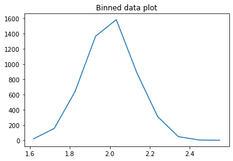

```python
x = [ (histogram[1][i+1] + histogram[1][i])/2 for i in range (len(histogram[1])-1)]
plt.plot(x,histogram[0])
plt.title("Binned data plot")
```

**Question: You will have to deal with the fact that the counts- and bin-arrays have different lengths. Explain how you deal with this problem and why.**

*To deal with the different length problem, we can replace intervals by the center point of each interval for x-axis. Thus, we obtain 10 center points for 10 y-axis values*

**Binning integers**

But binning real numbers into a fixed number of bins is easy when `numpy.histogram` does all the work and finds the right bin boundaries for you. Now we'll generate a bunch of integers and set the bin boundaries manually.

- This time, let's grab data from a Poisson distribution. As it turns out `numpy` also has some convenient random number generators. Use `numpy.random.poisson` to generate 5000 numbers drawn from a Poisson distribution characterized by $\lambda = 10$. Find the maximum and minimum value of your 5000 random numbers.

```python
# Generating 5000 numbers drawn from Poisson distribution
lambdaa, N = 10, 5000
points = [np.random.poisson(lambdaa) for _ in range (N)]
```

```python
# Find max and min values
points_max, points_min = max(points),min(points)
print(f"(max value, min value) = ({points_max}, {points_min})")
```

```
(max value, min value) = (24, 1)
```

- Instead of simplify specifying the number of bins for `numpy.histogram`, let's specify the bins we want using a vector. Create a vector $v$ that results in a binning that puts each integer value in its own bin and where the first bin contains the minimum number you found above, and the last bin contains the maximum number.

```python
v = list(range(points_min,points_max+1))
```

```python
points_min, points_max
```

```
(1, 24)
```

**Question: you may want to think about how `numpy.histogram` deals with the smallest an largest value in particular; is it correct to set the first entry of $v$ to be equal to the smallest value you observe and the last entry of $v$ to be the highest value observed?**

*Yes, it is correct to process this way since all values are found between those two bounds.*

- Use the vector by setting `numpy.histogram`'s `bin` parameter as `bin =` $v$.

```python
values, bins = np.histogram(points, bins=v)
```

```python
values
```

```
array([  4,  13,  37,  99, 197, 313, 452, 583, 596, 662, 578, 446, 373,
       235, 162, 114,  66,  34,  21,   8,   5,   1,   1], dtype=int64)
```

```python
bins
```

```
array([ 1,  2,  3,  4,  5,  6,  7,  8,  9, 10, 11, 12, 13, 14, 15, 16, 17,
       18, 19, 20, 21, 22, 23, 24])
```

**Question: What is the sum over bin counts? Explain how the binning-vectors first and last element relates to the min and max from the Poisson distribution.**

```python
sum(values)
```

```
5000
```

*The first element of the binning-vectors is the min of the poisson distribution, while the last one is the max, as we set them in np.histogram. Thus we show that we can include all generated values taking max and min values as bin vector bounds.*

- Now, use a bar chart (`matplotlib.pyplot.bar`) to plot the distribution

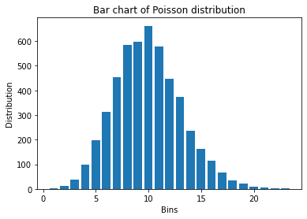

```python
plt.bar(x=bins[:-1],height=values)
plt.xlabel('Bins')
plt.ylabel('Distribution')
plt.title("Bar chart of Poisson distribution")
```

**Binning and plotting degree distributions.**

- Let's generate the Erdös-Renyi (ER) network which has a degree distribution that matches the Poisson distribution above. First we have to figure out which values the ER parameters (*N* and *p*) should assume.

**Question: It's easy to see that $N = 5000$, but how do you find $p$?** (Hint: The parameter $\lambda$ in the Poisson distribution corresponds to the average degree, so you have to find a $p$ that results in an average degree, $k = 10$. And you know that $\langle k \rangle = p (N-1)$, which will give you $p$.)

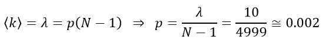

- Now, use `networkx` to create the graph and extract the degree distribution.

```python
N, k = 5000, 10
p = k/(N-1)

# ER graph creation
G_ER = nx.erdos_renyi_graph(N,p)
```

```python
# degree distribution extraction
all_degrees = [G_ER.degree(node) for node in list(G_ER.nodes)]
```

- Finally, create a nice bar plot of the degree distribution, including axes labels and a plot title. Make sure that it looks like the Poisson distribution you plotted above.

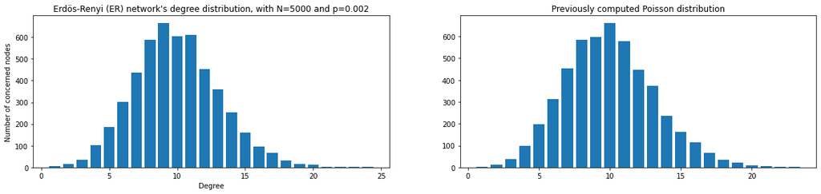

```python
# Find max and min values
max_points, min_points = max(all_degrees), min(all_degrees)

# Construct v-vector as before
v = list(range(min_points, max_points + 1))

# Get histogram
values_ER, bins_ER = np.histogram(all_degrees, bins = v)

# Plot bar plot of the degree distribution and previous Poisson distribution for comparison
plt.figure(figsize=[20,4])

_ = plt.subplot(121)
plt.title(f"Erdös-Renyi (ER) network's degree distribution, with N={N} and p={round(p,3)}")
plt.xlabel("Degree")
plt.ylabel("Number of concerned nodes")
plt.bar(x = bins_ER[:-1], height = values_ER)

_ = plt.subplot(122)
plt.bar(x=bins[:-1],height=values)
plt.title("Previously computed Poisson distribution")
```

*We note that both distributions have similar shape and scale.*

# Part 2: Random networks and plotting in `networkx`

- In your notebook, work through NS exercise 3.1 ('Erdős-Rényi Networks'). The exercise can be found in Section 3.11: Homework.

**Erdős-Rényi Networks**

Consider an Erdős-Rényi network with $N = 3000$ nodes, connected to each other with probability $p = 10^–3$.

**1. What is the expected number of links, 〈L〉?**

```python
p, N = 10**(-3), 3000
L_avg = p*N*(N-1)/2
print(f"〈L〉 = {L_avg}")
```

```
〈L〉 = 4498.5
```

**2. In which regime is the network?**

Network **regimes**, based on probability $p$:

- **subcritical**: $p$ < 1/$N$
- **supercritical**: $p$ > 1/$N$
- **connected**: $p$ > ln$N$/$N$

```python
print(f"1/N = {1/N}")
print(f"ln(N)/N = {np.log(N)/N}")
```

```
1/N = 0.0003333333333333333
ln(N)/N = 0.0026687891892167486
```

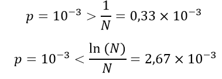

*Thus, based on network regime's definitions, the network is in **supercritical** regime.*

**3. Calculate the probability $p_c$ so that the network is at the critical point**

```python
pc = 1/N
print(f"pc = {pc}")
```

```
pc = 0.0003333333333333333
```

**4. Given the linking probability $p = 10^-3$, calculate the number of nodes $Ncr$ so that the network has only one component.**

*We can read in the Network Science book that:*

> Only the actor network is in the connected regime, meaning that all nodes are part of a single giant component. Note that while the boundary between the subcritical and the supercritical regime is always at ‹k› = 1, the boundary between the supercritical and the connected regime is at lnN, which varies from system to system.

*Thus, the network has only one component if ‹k› = ln(N). We know that ‹k› = p(N-1), so we have to **solve ln(N) = p(N-1)**.*

*Let's solve it graphically through approximation.*

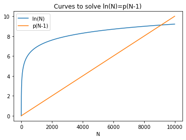

```python
x_points = list(range(1,10000))
y1 = [ np.log(x) for x in x_points]
y2 = [p*(x-1) for x in x_points]

plt.plot(x_points,y1)
plt.plot(x_points,y2)
plt.title("Curves to solve ln(N)=p(N-1)")
plt.xlabel('N')
_ = plt.legend(['ln(N)','p(N-1)'])
```

```python
# Find the abscisse of intersection
i0=1
while i0<len(x_points):
    if (y2[i0]<y1[i0]):
        i0+=1
    else:
        break;
Ncr = x_points[i0]
print(f"Ncr = {Ncr}")
```

```
Ncr = 9120
```

**5. For the network in (d), calculate the average degree 〈kcr〉 and the average distance between two randomly chosen nodes 〈d〉.**

```python
kcr_avg = p*(Ncr-1)
print(f"〈K_cr〉 = {kcr_avg}")
```

```
〈K_cr〉 = 9.119
```

```python
d_avg = np.log(Ncr)/np.log(kcr_avg)
print(f"〈d〉 = {d_avg}")
```

```
〈d〉 = 4.12522144293705
```

**Paths**

- Plot a random network with 200 nodes and an average degree of 1.5. (I suggest using `networkx.draw` and reading [the documentation](https://networkx.github.io/documentation/stable/reference/drawing.html) carefully to get an overview of all the options and what they look like. For example, you may want to shrink the node size).

```python
# Create the random network
N, k_avg = 200, 1.5
l_avg = N*k_avg/2

Grd = nx.gnm_random_graph(N,l_avg)
```

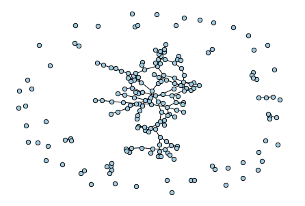

```python
# Plot the network properly
options = {
    'node_size': 40,
    'edgecolors':'black',
    'node_color':'#A0CBE2'
}

nx.draw(Grd,**options)
```

- Extract the Giant Connected Component, GCC. (Hint. You can use `networkx.connected_component_subgraphs`)

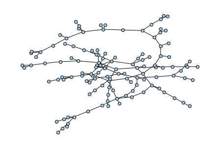

```python
GCC = list(nx.connected_components(Grd))
GCC.sort(key=len)
concerned_nodes = GCC[-1]

GCC = Grd.subgraph(concerned_nodes).copy()

nx.draw(GCC,**options)
```

- Choose a node at random from the GCC. (Hint: You may want to try `random.choice`.)

```python
rd_node = rd.choice(list(GCC.nodes()))
print(f"We randomly chose the node n°{rd_node}")
```

```
We randomly chose the node n°5
```

- Find all nodes that are precisely 2 steps away from that node. (Hint. I suggest `networkx.single_source_shortest_path_length`)

```python
twosteps_nodes = list(set(nx.single_source_shortest_path_length(GCC,rd_node,2))-set(nx.single_source_shortest_path_length(GCC,rd_node,1)))
print(f"All nodes precisely 2 steps away from our node are : {list(twosteps_nodes)}")
```

```
All nodes precisely 2 steps away from our node are : [40, 145]
```

- Plot the GCC with the following choice of colors. Starting node *black* (`"#000000"`). The nodes 2 steps away *red* (`"#ff0000"`). All other nodes *blue* (`"#A0CBE2"`). Again, I suggest using `networkx.draw()` and reading [the documentation](https://networkx.github.io/documentation/stable/reference/drawing.html) carefully find out how to color individual nodes.

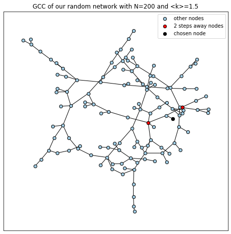

```python
pos = nx.spring_layout(GCC)

options = {
    'node_size': 40,
    'edgecolors':'black'
}

fig, ax = plt.subplots(figsize=(8, 8))
plt.title("GCC of our random network with N=200 and <k>=1.5")
nx.draw_networkx_nodes(GCC,pos=pos, node_color='#A0CBE2', **options)
nx.draw_networkx_nodes(GCC,pos=pos, nodelist=twosteps_nodes, node_color='#ff0000', **options)
nx.draw_networkx_nodes(GCC,pos=pos, nodelist=[rd_node],node_color='black', **options)
nx.draw_networkx_edges(GCC,pos=pos)

plt.legend(['other nodes', '2 steps away nodes','chosen node'])
```

# Part 3: Watts-Strogatz Networks

- First, let's use `networkx` to play around with WS graphs. Use `nx.watts_strogatz_graph` to generate 3 graphs with 500 nodes each, average degree = 4, and rewiring probablity $p = 0, 0.1,$ and $1$.

```python
N = 500  # nodes
k =  4  # average degree
p = [0, 0.1, 1]  # rewiring probability

# Generating three Watts-Strogatz graphs with same number of nodes
# and same average degree but different rewiring probability

WS = [] # list of graphs
for j in range(len(p)):
    WS.append(nx.watts_strogatz_graph(N, k, p[j]))
```

- Calculate the average shortest path length $\langle d \rangle$ for each one.

```python
d = []  # list of <d>
for aGraph in WS:
    d.append(nx.average_shortest_path_length(aGraph))

print('The average shortest path length <d> for each Watts-Strogatz graph is:')
print(d)
```

```
The average shortest path length <d> for each Watts-Strogatz graph is:
[62.875751503006015, 7.621482965931864, 4.738356713426854]
```

**Question: Describe what happens to the network when $p = 1$.**

For $p = 1$, all links are rewired and the model turns into a fully randomized network. The average shortest path length $\langle d \rangle$ gets closer to the $\langle k \rangle$ we gave as initial parameter. However the clustering is getting low. We can display the three graphs to visualise and better understand this transformation when $p$ increases.

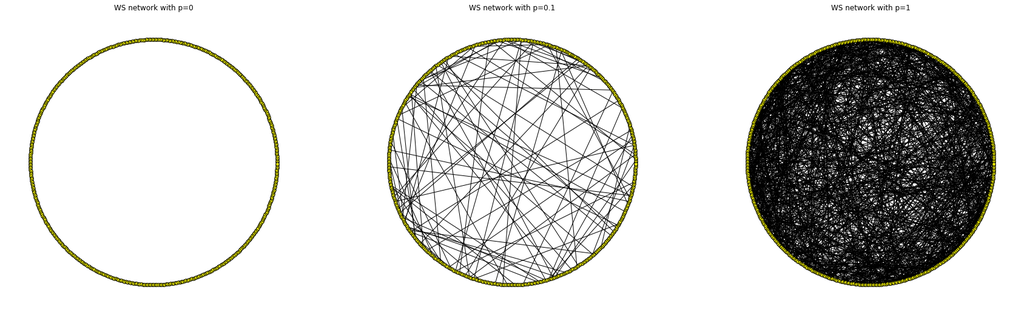

```python
options = {
    'node_size': 30,
    'edgecolors':'black',
    'node_color':'yellow'
}

plt.figure(figsize=[30,9])

subax1 = plt.subplot(131)
plt.title("WS network with p=0")
nx.draw_circular(WS[0], **options)

subax2 = plt.subplot(132)
plt.title("WS network with p=0.1")
nx.draw_circular(WS[1], **options)

subax1 = plt.subplot(133)
plt.title("WS network with p=1")
nx.draw_circular(WS[2], **options)
```

- Let's understand the behavior of the WS model as we increase $p$ in more detail. Generate 50 networks with $N = 500$, $\langle k \rangle = 4$, for each of $p = \{0, 0.01, 0.03, 0.05, 0.1, 0.2\}$.

```python
N = 500  # nodes
k = 4  # average degree

WSL = [] # list of lists of networks for each p, len(WSL) = 6, len(WSL[0]) = 50
p = [0, 0.01, 0.03, 0.05, 0.1, 0.2]
for j in range(len(p)):
    WS = []  # list of 50 networks for specific p, len(WS) = 50
    for i in range(50):
        WS.append(nx.watts_strogatz_graph(N, k, p[j]))
    WSL.append(WS)
```

- Calculate the average of $\langle d \rangle$ as well as the standard deviation over the 50 networks, to create a plot that shows how the path length decreases very quickly with only a little fraction of re-wiring. Use the standard deviation to add [errorbars](https://matplotlib.org/3.1.1/api/_as_gen/matplotlib.pyplot.errorbar.html) to the plot.

```python
d_50 = np.array([]) # list of the average of <d> for each p
std = np.array([]) # list of teh standard deviation for each p

for i in range(len(WSL)):
    d=np.array([])
    for j in WSL[i]:
        # the average shortest path length <d> for each network (for each p)
        d = np.append(d, nx.average_shortest_path_length(j))
        # len(d) = 50

    d_50 = np.append(d_50, np.mean(d))
    std = np.append(std, np.std(d))
```

```python
print(f"List of measured averages : {d_50.tolist()}")
print(f"List of measured std : {std.tolist()}")
```

```
List of measured averages : [62.87575150300602, 23.774780761523044, 13.230489619238476, 10.339254669338677, 7.688951983967935, 6.123528336673346]
List of measured std : [7.105427357601002e-15, 4.537420504848286, 1.0598109267086244, 0.6719824607948691, 0.30119155689327176, 0.12786494413473998]
```

```
<ErrorbarContainer object of 3 artists>
```

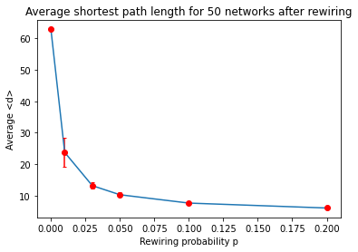

```python
# Creating the plot

plt.figure
plt.plot(p,d_50)
plt.title('Average shortest path length for 50 networks after rewiring')
plt.xlabel('Rewiring probability p')
plt.ylabel('Average <d>')
plt.errorbar(p,d_50.tolist(), yerr = std.tolist(), xerr=None, capsize = 2, fmt = 'ro', label = 'standard deviation')
```

# Part 4. The Barabasi-Albert Model

We're going to create our own Barabasi-Albert model (a special case) in a `notebook`. Follow the recipe below for success

- Create a 100 node BA network using a BA model that you've coded on your own (so don't use the built-in NetworkX function, but the one you created during week 3). And plot it using NetworkX.

```python
# This is the function we created during Week 3 to generate a BA network

def create_ba_graph(number_of_nodes):
    """the function generates a BA graph with the
    desired number of nodes"""

    # first create a graph consisting of a single link
    G = nx.Graph()
    G.add_nodes_from([1,2])
    G.add_edge(1,2)

    new_node_label = 3

    # adding new nodes until desired number of nodes
    for _ in range (number_of_nodes-2):
        G.add_node(new_node_label)
        flatten_list = list(sum(G.edges,()))
        target_label = rd.choice(flatten_list)
        G.add_edge(new_node_label,target_label)
        new_node_label += 1

    return G
```

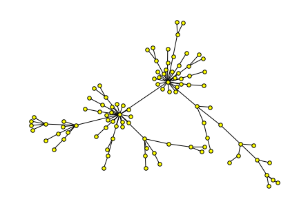

```python
# Creating a 100 node BA network
G1 = create_ba_graph(100)

# Plot 100-node-graph
options = {
    'node_size': 30,
    'edgecolors':'black',
    'node_color':'yellow'
}
nx.draw_spring(G1, **options)
plt.show()
```

- Now create a 5000 nodes network.

```python
print("Generating 5000 nodes graph")
G5k = create_ba_graph(5000)
```

```
Generating 5000 nodes graph
```

**Question: What's the maximum and minimum degree?**

```python
# retrieving all the degrees of the graph manipulating as a dict
all_degrees = list(dict(G5k.degree).values())

# max, min degree
max_degree = max(all_degrees)
min_degree = min(all_degrees)
print(f"Max degree is {max_degree} and min degree is {min_degree}")
```

```
Max degree is 159 and min degree is 1
```

- Now, bin the degree distribution, for example using `numpy.histogram`.

```
<BarContainer object of 158 artists>
```

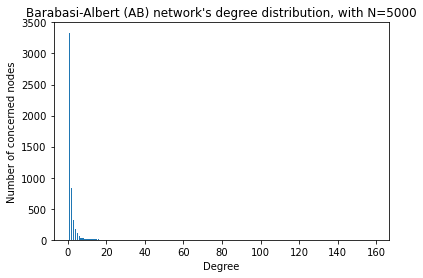

```python
# binning the degree distribution
hist_AB = np.histogram(all_degrees,bins=(max_degree-min_degree))
# plot histogram
plt.title(f"Barabasi-Albert (AB) network's degree distribution, with N=5000")
plt.xlabel("Degree")
plt.ylabel("Number of concerned nodes")
plt.bar(x = hist_AB[1][:-1], height = hist_AB[0])
```

- Plot the distribution. Plot it with both linear and log-log axes.

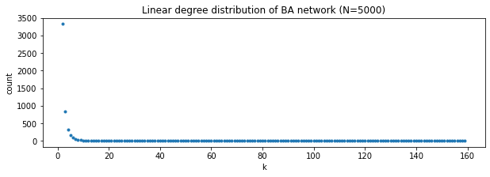

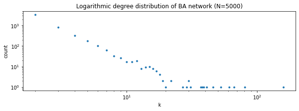

```python
# plotting linear
plt.figure(figsize=[10,3])
plt.title("Linear degree distribution of BA network (N=5000)")
plt.ylabel("count")
plt.xlabel("k")
plt.plot(hist_AB[1][1:], hist_AB[0], marker='o', markersize=3, linestyle=' ')

# plotting log
plt.figure(figsize=[10,3])
plt.title("Logarithmic degree distribution of BA network (N=5000)")
plt.ylabel("count")
plt.xlabel("k")
plt.loglog((hist_AB[1][1:]), (hist_AB[0]),marker='o',markersize=3, linestyle=' ')
```

# Part 5 Power-laws and the friendship paradox

Next step is to explore the [Friendship paradox](https://en.wikipedia.org/wiki/Friendship_paradox). This paradox states that *almost everyone* have fewer friends than their friends have, on average. This sounds crazy, but is actually an almost trivial consequence of living in a social network with a power-law degree distribution. The explanation is that almost everyone is friends with a hub, that drives up the average degree of the friends. Let's explore that in the 5000 node BA network we've just generated. Do the following:

- Pick a node *i* at random (e.g. use `random.choice`). [Find its degree](http://networkx.lanl.gov/reference/generated/networkx.Graph.degree.html).

```python
# a random node i from the network
i = rd.choice(list(G5k.nodes))

# i's degree
k_i = G5k.degree(i)

print('The random pick is node', i, 'having degree', k_i)
```

```
The random pick is node 3896 having degree 1
```

- Find *i*'s [neighbors](http://networkx.lanl.gov/reference/generated/networkx.Graph.neighbors.html). And calculate their average degree.

```python
# list of i's neighbors
i_nei = list(G5k.neighbors(i))

# i's neighbors degree
k_i_nei = np.mean(np.array(list((dict(G5k.degree(i_nei))).values())))

print('The neighbors are ', i_nei, 'having average degree', k_i_nei)
```

```
The neighbors are  [3510] having average degree 2.0
```

- Compare the two numbers to check if it's true that *i*'s friends (on average) have more friends than *i*.

```python
print(f"In this case, it's {k_i < k_i_nei} that i's friends, on average, have more friends than i.")
```

```
In this case, it's True that i's friends, on average, have more friends than i.
```

- Do this 1000 times. How many out of those 1000 times is the friendship paradox true?

```python
fail_friendship_paradox = 0
for _ in range (1000):
    i_rd = rd.choice(list(G5k.nodes)) #Pick a node i at random
    d_rd = G5k.degree[i_rd] #Find its degree
    neighbors_list = list(G5k.neighbors(i_rd)) #Find i's neighbors
    avg_degree = np.mean([G5k.degree(neighbor) for neighbor in neighbors_list])  #Calculate their average degree
    #Compare them
    if avg_degree <= d_rd:
        fail_friendship_paradox += 1
print(f"Friendship paradox works {100 - round(100*fail_friendship_paradox/1000,2)}% of times among 1000 tests")
```

```
Friendship paradox works 85.9% of times among 1000 tests
```

- Compare to the ER network of same size and same $p$.

```python
# build a ER network of same size and same p (here, l_avg = N)
N = 5000
Grd = nx.gnm_random_graph(N,N)
```

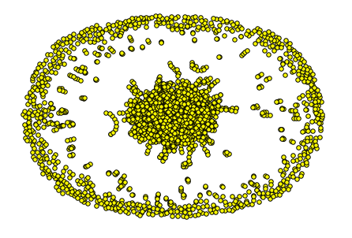

```python
# plot the ER network
nx.draw_spring(Grd, **options)
```

**Question: What are the differences? Explain in your own words.** (Hint: To get started, take a look at the degree distribution, and study the number of connected components.)

*First, let's see what are the extreme degrees in this network.*

```python
all_degrees_rd = list(dict(Grd.degree).values())
max_degree_rd, min_degree_rd = max(all_degrees_rd), min(all_degrees_rd)
print(f"For the ER network: maximum degree is {max_degree_rd}, and minimum degree is {min_degree_rd} ")
print(f"As a reminder, for AB network : maximum degree was {max_degree} and minimum degree was {min_degree}")
```

```
For the ER network: maximum degree is 7, and minimum degree is 0
As a reminder, for AB network : maximum degree was 159 and minimum degree was 1
```

*Then, let's study the degree distribution and the number of connected components, as suggested in "Hint"*

```
<BarContainer object of 158 artists>
```

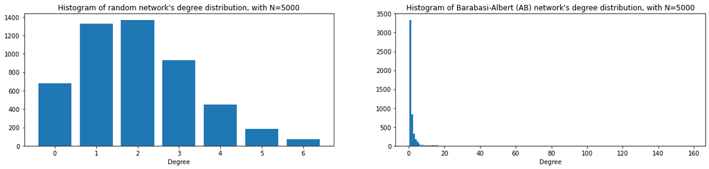

```python
# Plot the histogram of degree distribution in ER case and previous AB case for comparison
plt.figure(figsize=[20,4])

_ = plt.subplot(121)
histogram_rd = np.histogram(all_degrees_rd,bins=(max_degree_rd-min_degree_rd))
plt.title("Histogram of random network's degree distribution, with N=5000")
plt.xlabel("Degree")
plt.bar(x = histogram_rd[1][:-1], height = histogram_rd[0])

_ = plt.subplot(122)
plt.title(f"Histogram of Barabasi-Albert (AB) network's degree distribution, with N=5000")
plt.xlabel("Degree")
plt.bar(x = hist_AB[1][:-1], height = hist_AB[0])
```

```python
# number of connected components
connected_components_list = list(nx.connected_components(Grd))
connected_components_nbEdges = np.array([ Grd.subgraph(aSubgraph).number_of_edges() for aSubgraph in connected_components_list])
print(f"There are {len(connected_components_list)} connected components in our ER network")
ratio_sup2components = len(np.argwhere(connected_components_nbEdges > 2))/len(connected_components_list)
print(f"{round(ratio_sup2components*100,2)}% of those connected components have more than 2 edges")
```

```
There are 799 connected components in our ER network
3.63% of those connected components have more than 2 edges
```

*All degrees are at the vicinity of $\langle k \rangle$ = $2*avg(L)/N = 2$. Indeed, a very few percentage of connected components has more than 2 edges, and the histogram of degree distribution shows that all values are centered aroung small degrees.*

*The degree distribution is a Poisson-like distribution, and the max is not located at smallest values anymore. It's less spread than in AB case.*

## Assignment 1 - THE END

*Thanks for reading!*